# Getting Started

```r
library(ggplot2)
library(ggprism)
library(patchwork)
```

The goal of this package is to enable R users to format their ggplots to look like they were made in GraphPad Prism. I moved away from Prism to R for statistics quite a while ago, however I missed the ‘look’ that GraphPad Prism graphs have. Which is how I got the idea to make this package.

This document outlines what features are available in `ggprism` and has links to guides with more detailed examples of how to use each function.

## Themes

The most useful function in this package is `theme_prism()` which is a ‘complete’ theme which works just like any other standard ggplot2 theme e.g. `theme_grey()`. The standard theme palette is `"black_and_white"` but there are many others which correspond to the colour schemes available in Prism. Go to the [All Palettes](https://csdaw.github.io/ggprism/articles/web-only/palettes.html) page to see all the available palettes.

See [this guide](https://csdaw.github.io/ggprism/articles/themes.html) for more detailed usage examples.

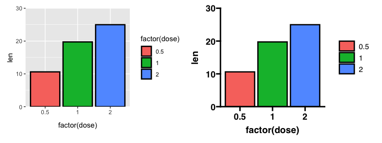

```r
# compare theme_grey() to theme_prism()
p1 <- ggplot(ToothGrowth, aes(x = factor(dose), y = len)) +
  stat_summary(aes(fill = factor(dose)), na.rm = TRUE,
               geom = "col", fun = mean, colour = "black", linewidth = 0.9) +
  scale_y_continuous(limits = c(0, 30), expand = c(0, 0))

p2 <- p1 + theme_prism(base_size = 14)

p1 + p2
```

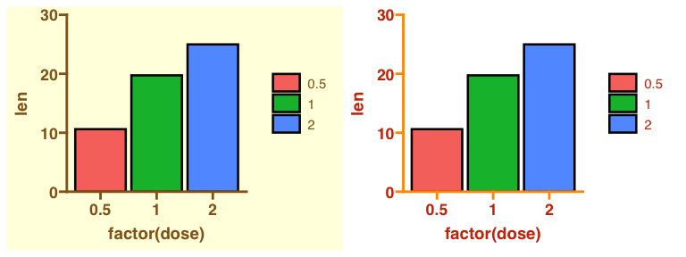

```r
# compare some of the available theme palettes
p3 <- p1 + theme_prism(palette = "mustard_field", base_size = 14)
p4 <- p1 + theme_prism(palette = "flames", base_size = 14)

p3 + p4
```

## Colours, fills, and shapes

`ggprism` includes the functions `scale_colour_prism()`/`scale_color_prism()` and `scale_fill_prism()` which make the colour schemes from Prism available for use with ggplot2 geoms and stats. You can either use them with the default `"black_and_white"` theme or try matching themes and colour/fill scales.

See the [this guide](https://csdaw.github.io/ggprism/articles/colours.html) for more detailed usage examples.

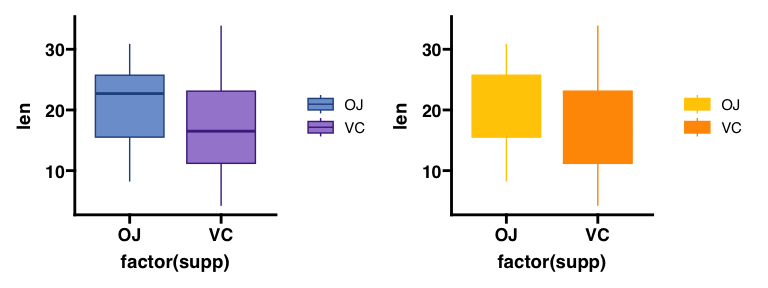

```r
# compare some colour and fill palettes with default theme_prism()
p <- ggplot(ToothGrowth, aes(x = factor(supp), y = len)) +
  geom_boxplot(aes(colour = factor(supp), fill = factor(supp))) +
  theme_prism(base_size = 14)

p1 <- p + scale_colour_prism(palette = "floral") +
  scale_fill_prism(palette = "floral")

p2 <- p + scale_colour_prism(palette = "flames") +
  scale_fill_prism(palette = "flames")

p1 + p2
```

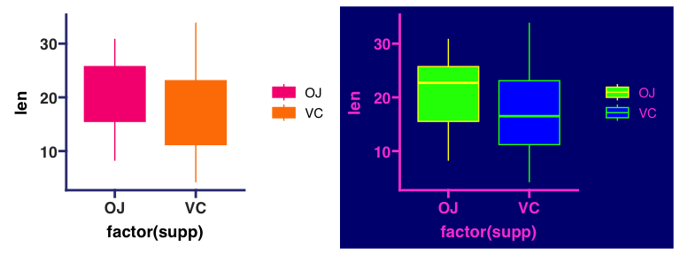

```r
# try using the same palette for colour, fill, and theme
p <- ggplot(ToothGrowth, aes(x = factor(supp), y = len)) +
  geom_boxplot(aes(colour = factor(supp), fill = factor(supp)))

p3 <- p + theme_prism(palette = "candy_bright") +
  scale_colour_prism(palette = "candy_bright") +
  scale_fill_prism(palette = "candy_bright")

p4 <- p + theme_prism(palette = "neon") +
  scale_colour_prism(palette = "neon") +
  scale_fill_prism(palette = "neon")

p3 + p4
```

Additionally, `scale_shape_prism()` includes some shape scales which roughly match the shapes (and order of shapes) used in GraphPad Prism.

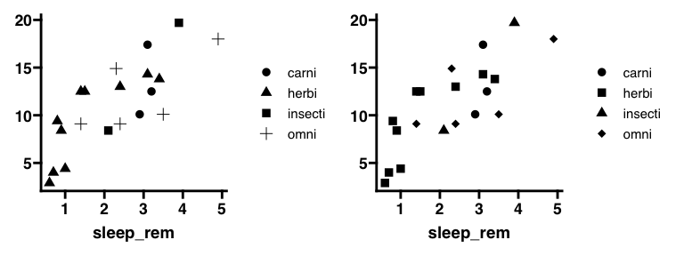

```r
# compare ggplot2 default shape order with ggprism default shape order
p1 <- ggplot(msleep[complete.cases(msleep), ],
             aes(x = sleep_rem, y = sleep_total)) +
  geom_point(aes(shape = factor(vore)), size = 3) +
  theme_prism() +
  theme(axis.title.y = element_blank())

p2 <- p1 + scale_shape_prism()

p1 + p2
```

## Axes

`ggprism` includes several axis guides which can be used to change the look of continuous (or in some cases discrete) axes. These guides work best with `theme_prism()` but can also be used with any other ggplot2 theme which has axis lines e.g. `theme_classic()` or `theme_bw()`.

See the [this guide](https://csdaw.github.io/ggprism/articles/axes.html) for more detailed usage examples.

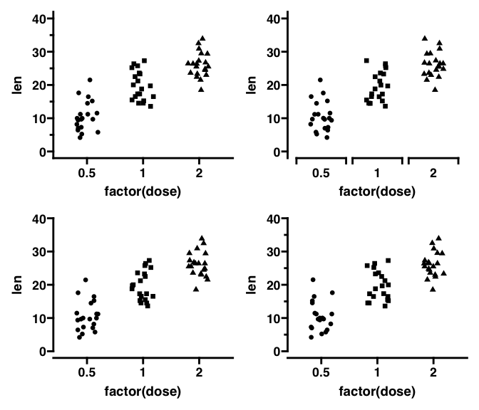

```r
# show the 4 different axis guides included in ggprism
p <- ggplot(ToothGrowth, aes(x = factor(dose), y = len)) +
  geom_jitter(aes(shape = factor(dose)), width = 0.2, size = 2) +
  scale_shape_prism() +
  theme_prism() +
  theme(legend.position = "none")

p1 <- p + scale_y_continuous(limits = c(0, 40), guide = "prism_minor")

p2 <- p + scale_x_discrete(guide = "prism_bracket") +
  scale_y_continuous(limits = c(0, 40))

p3 <- p + scale_y_continuous(limits = c(0, 40), guide = "prism_offset")

p4 <- p + scale_y_continuous(limits = c(0, 40), guide = "prism_offset_minor")

(p1 + p2) / (p3 + p4)
```

## p-values

`ggprism` includes the `add_pvalue()` function to easily add p-values from a simple data.frame to your plots. This function is a re-written version of `stat_pvalue_manual()` from the [`ggpubr` package](https://github.com/kassambara/ggpubr). `add_pvalue()` is more flexible to different inputs than `stat_pvalue_manual()` and also allows you to change the look of the brackets and text more easily.

See the [this guide](https://csdaw.github.io/ggprism/articles/pvalues.html) for more detailed usage examples.

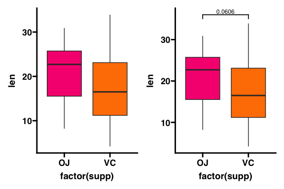

```r
# make a p-value table
df_p_val <- data.frame(
  group1 = "OJ",
  group2 = "VC",
  p.adj = 0.0606,
  y.position = 36
)

# make a plot
p1 <- ggplot(ToothGrowth, aes(x = factor(supp), y = len)) +
  geom_boxplot(aes(fill = factor(supp))) +
  scale_fill_prism(palette = "candy_bright") +
  theme_prism() +
  theme(legend.position = "none")

# add the p-value
p2 <- p1 + add_pvalue(df_p_val)

p1 + p2
```